# R Notebook

# Add packages

```r
require("sf")
```

```r
require("ggplot2")
```

## Make plots with facets

Composite graphics are often a feature in scientific publications. These may combine maps with other plots to provide a more holistic representation of data and context.

First, let’s add some data:

```r
dates<-read.csv("SARadiocarbon.csv")
datesSF<-st_as_sf(dates,coords=c("LONGITUDE","LATITUDE"))
border<-st_read("south_africa_border.shp")
```

There are several ways to deal with composing a graphic from multiple parts in R, but probably the easiest is to use what are called *grobs*. Grob stands for ‘grid graphical object’, and for the most part grobs are comprised to ggplot objects that can be arranged in a graphical space.

To use this approach, we’ll use the `gridExtra` package.

```r
require("gridExtra")
```

This package offers a number of ways to deal with compositing images, but probably the easiest way is to use a matrix layout.

```r
lay <- rbind(c(1,1,2,2),
             c(1,1,2,2),
             c(3,3,4,4),
             c(3,3,4,4))
```

Here I’ve created a 4x4 matrix, and given it some numbers. These numbers correspond to the order of ggplot items I am going to give it. SO the first will occupy the top left quarter of the space, the second will occupy the top right, and so on. Since they occupy full quarters of the space, the resultant grid of images should be 2x2.

Let’s see how this works in reality when I use `layout_matrix`:

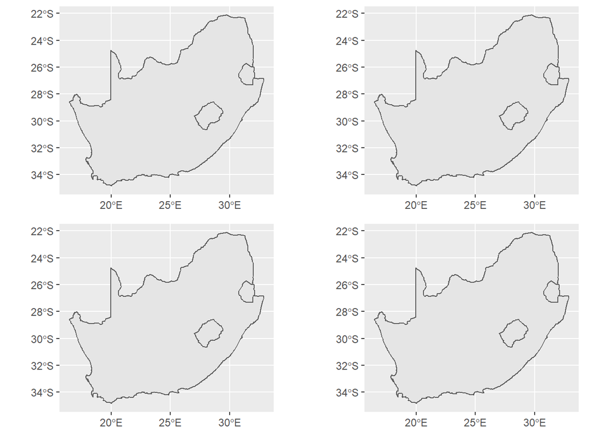

```r
p1<-ggplot() + geom_sf(data=border)

grid.arrange(p1,p1,p1,p1,layout_matrix = lay)
```

Just as I had hoped, now I have four instances of the same plot in a 2 x 2 grid.

The major benefit of this approach is that I can modify the space occupied by the different components to accommodate differently-sized plots. For instance, I can turn this plot into a set up with two images at the top and one at the bottom by modifying the matrix.

```r
lay <- rbind(c(1,1,2,2),
             c(1,1,2,2),
             c(3,3,3,3),
             c(3,3,3,3),
             c(3,3,3,3),
             c(3,3,3,3))
```

And now I send it 3 plots instead of 4:

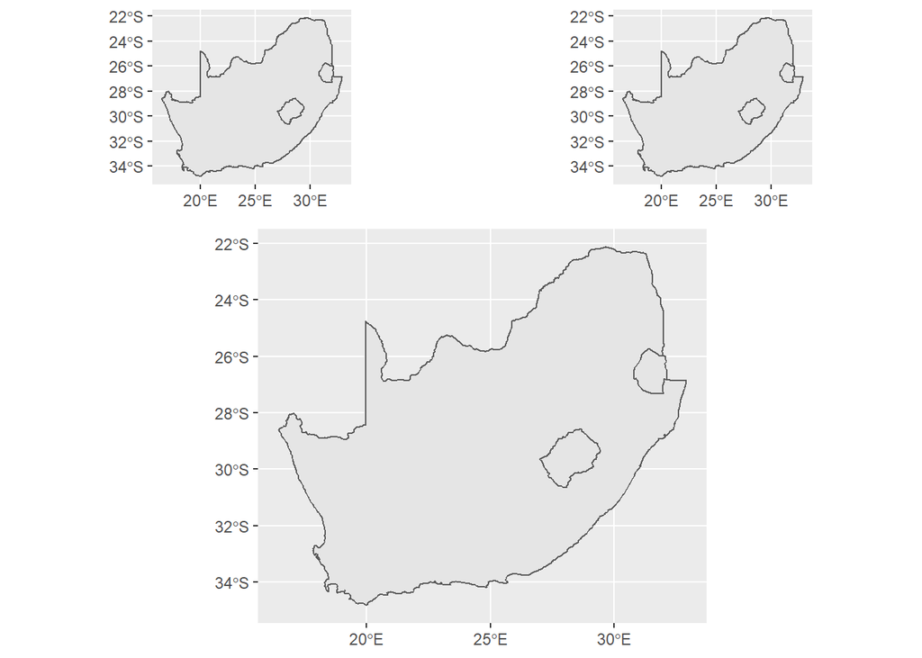

```r
grid.arrange(p1,p1,p1,layout_matrix = lay)
```

Voila!

## Try it yourself!

I almost forgot the radiocarbon dates! Today’s exercise is to subset this into six time periods:

- 40000 - 20000 BP
- 20000 - 12000 BP
- 12000 - 8000 BP
- 8000 - 4000 BP
- 4000 - 2000 BP
- 2000 - 0 BP

Create a matrix that can accommodate all of these and plot them on top of the SA border data.SS